# R Notebook

# functions

## functions

R does everything by copying. What do we mean by that?

```r
x <- 3
y <- x
x <- 2
x
y
```

## functions

R does everything by copying. What do we mean by that?

```r
x <- 3
y <- x
x <- 2
x
```

```
## [1] 2
```

```r
y
```

```
## [1] 3
```

## functions

- A `function` is a block of code that can be used multiple times. It is a way to structure the code.
- R provides many built-in functions that ease writing programs and executing codes.
- Examples: `print`, `:`, `c`, `in`

## functions

R also provides users with the ability to write their own custom functions

```r
printThanks <- function(){
  print("Thank you very much for running this code")
}

printThanks()
```

```
## [1] "Thank you very much for running this code"
```

## functions

```r
isEven <- function(x){
  if(x%%2==0){
    return(TRUE)
  }
  return(FALSE)
}
isEven(4)
```

```
## [1] TRUE
```

```r
x <- isEven(3)
x
```

```
## [1] FALSE
```

## functions

Variables defined inside a function are local to that function.

```r
x <- 5
testScope <- function(x){
  return(x+1)
}
testScope(4)
testScope(x)
x
```

## functions

Variables defined inside a function are local to that function.

```r
x <- 5
testScope <- function(x){
  return(x+1)
}
testScope(4)
```

```
## [1] 5
```

```r
testScope(x)
```

```
## [1] 6
```

```r
x
```

```
## [1] 5
```

## *apply

Functions in R become super useful together with the built-in apply functions. *apply helps you apply a function to each element of a vector or row/column of a matrix.

There are 3 main apply functions: `lapply`, `sapply` and `apply`. `lapply` - l stands for list, will return a list. `sapply` s stands for simple, will try to simplify the list. `apply` is `sapply` for matrices and data.frames.

## sapply

Here is an sapply example:

```r
isEven <- function(x){
  if(x%%2==0){
    return(TRUE)
  }
  return(FALSE)
}

myVec <- c(4,3,2,1)
sapply(myVec, isEven)
```

```
## [1]  TRUE FALSE  TRUE FALSE
```

## apply

`apply`, unlike sapply and lapply, takes 3 arguments: the data to apply over, which dimensions to apply over, and the function to apply.

Heres a simple example, using the built-in `sum` function, which returns the sum of a vector:

```r
my.mat <- matrix(1:4, nrow=2, ncol=2)
my.mat
apply(my.mat, 1, sum)
apply(my.mat, 2, sum)
```

```
##      [,1] [,2]
## [1,]    1    3
## [2,]    2    4
## [1] 4 6
## [1] 3 7
```

## functions

R has many built-in functions that can ease writing programs and you can find their syntax by using `?` operator

Examples:

```r
?mean
?rownames
```

```
## Help on topic 'rownames' was found in the following packages:
##
##   Package               Library
##   tibble                /home/arvind/.R
##   DBI                   /home/arvind/.R
##   base                  /usr/lib/R/library
##
##
## Using the first match ...
```

```r
?read.csv
```

## Exercise

Write a function will return T if a given element exists in a given vector.

## Exercise

```r
exists <- function(vector, element){

  for (v1 in vector) {
    if(v1 == element){
      return(TRUE)
    }
  }
  return(FALSE)
}
```

# Plots

## Plots

Plotting in R is easy:

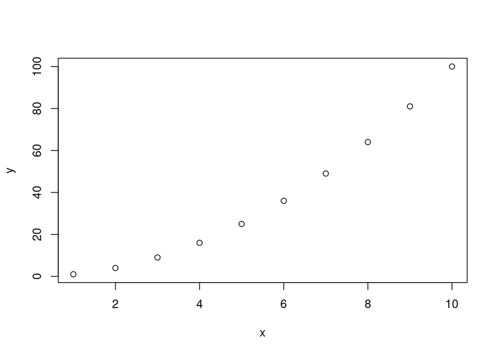

```r
x = 1:10
y = x**2
plot(x, y)
```

## Plot

Lets change color

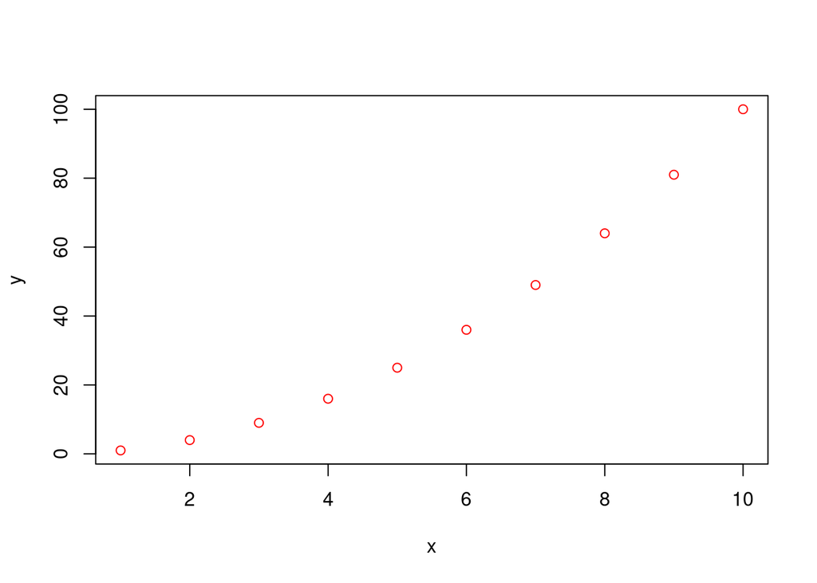

```r
plot(x, y, col = "red")
```

## Plot

Lets change point type

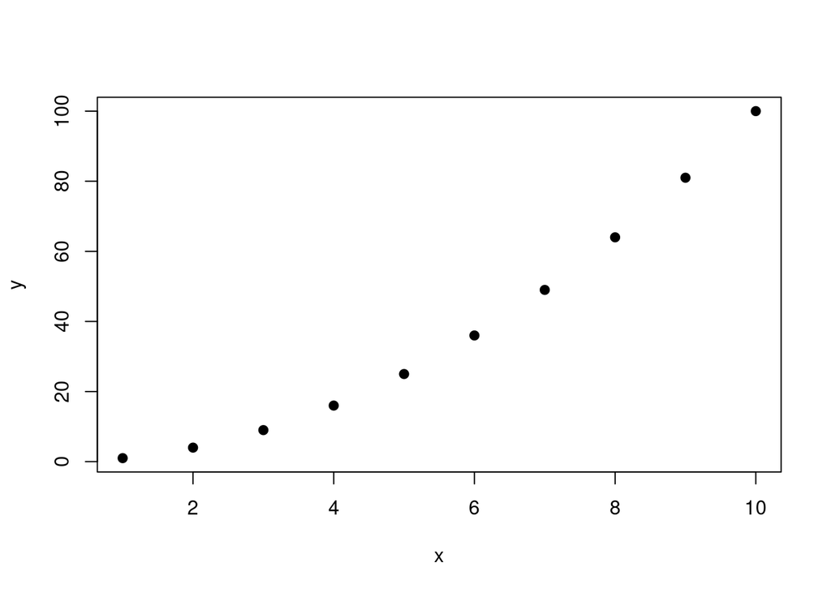

```r
plot(x, y, pch = 19)
```

## PCH

PCH (plotting character) is an argument to specify point shapes

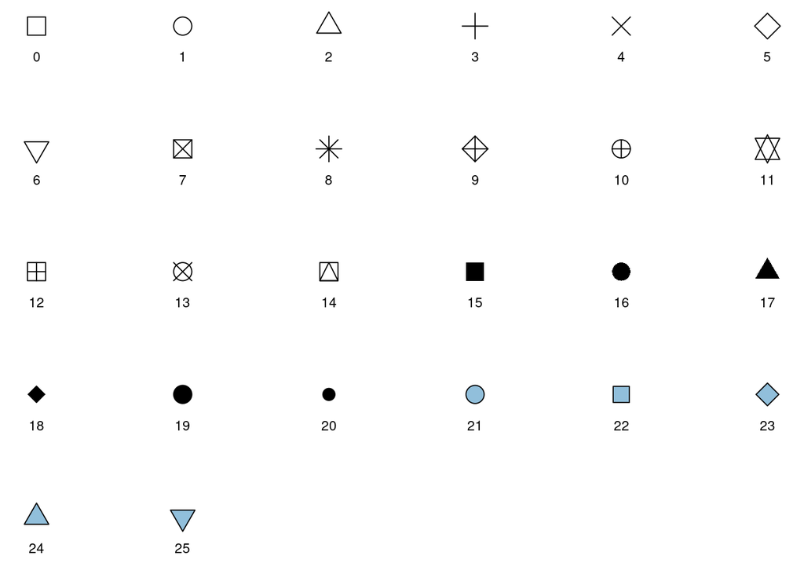

## PCH

[output not shown]

## Plot

- For PCH 21 to 25, background color can be specified

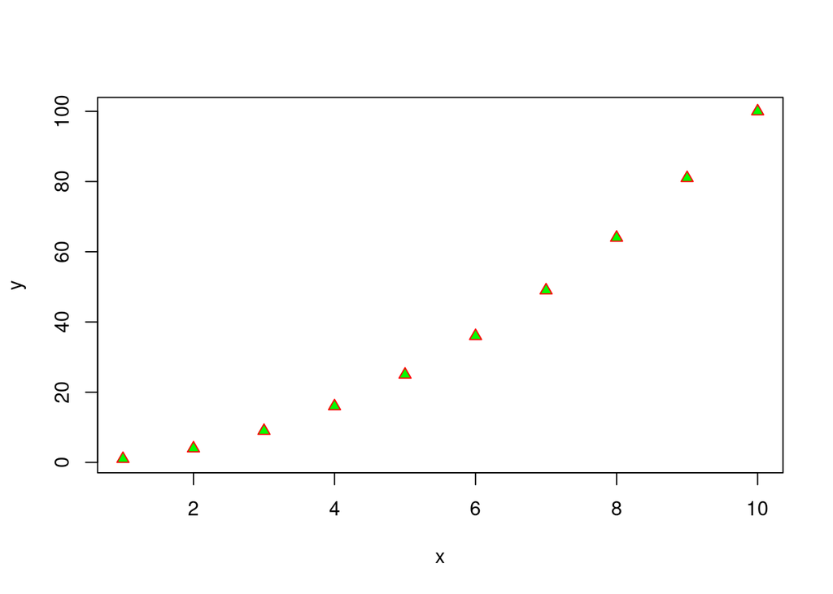

```r
plot(x, y, pch = 24, col="red", bg="green")
```

## Task

- plot data points in your favorite color and shape

## Plot Line

The option `"type"` can change the plot type

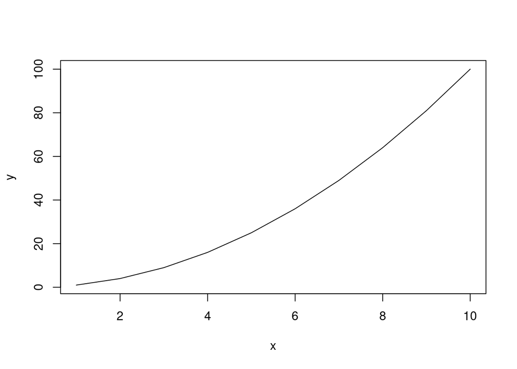

```r
plot(x, y, type = "l")
```

## Plot type

| “p” | for points |
| --- | --- |
| “l” | for lines |
| “b” | for both |
| “c” | for the lines part alone of “b” |
| “o” | for both ‘overplotted’ |
| “h” | for ‘histogram’ like (or ‘high-density’) vertical lines |
| “s” | for stair steps |
| “S” | for other steps |
| “n” | for no plotting |

## Plot

Lets plot both point and line

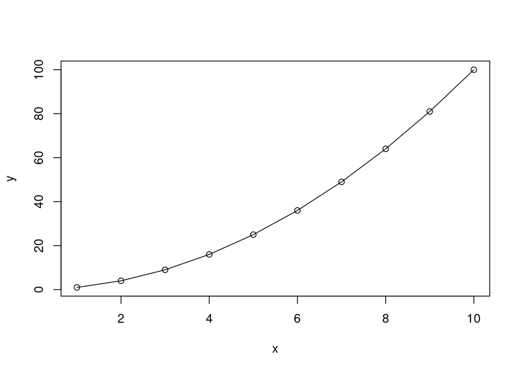

```r
plot(x, y, type = "o")
```

## Change line type

The option `"lty"` can change the line type

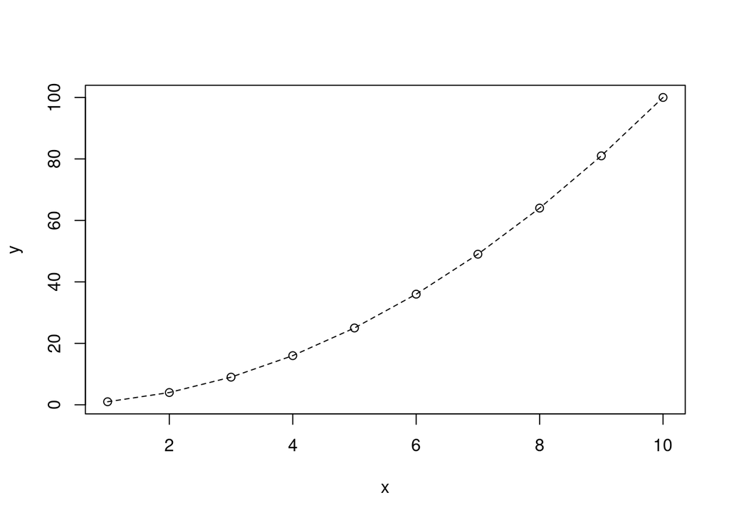

```r
plot(x, y, type = "o", lty=2)
```

## Line types in R

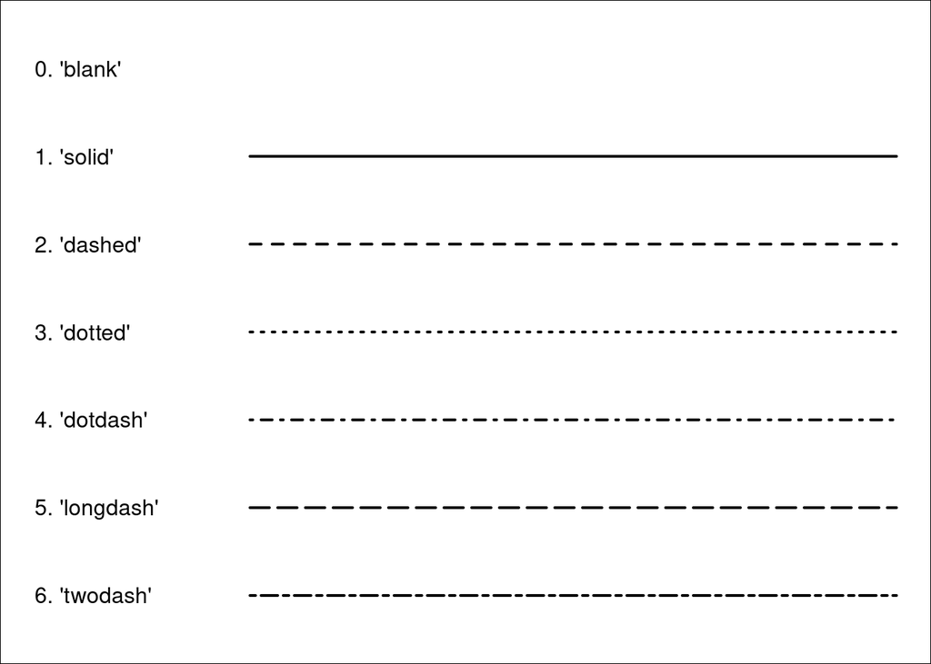

## Task

- plot data points and line in your favorite color and shape

## Plot Title

Give plot a title

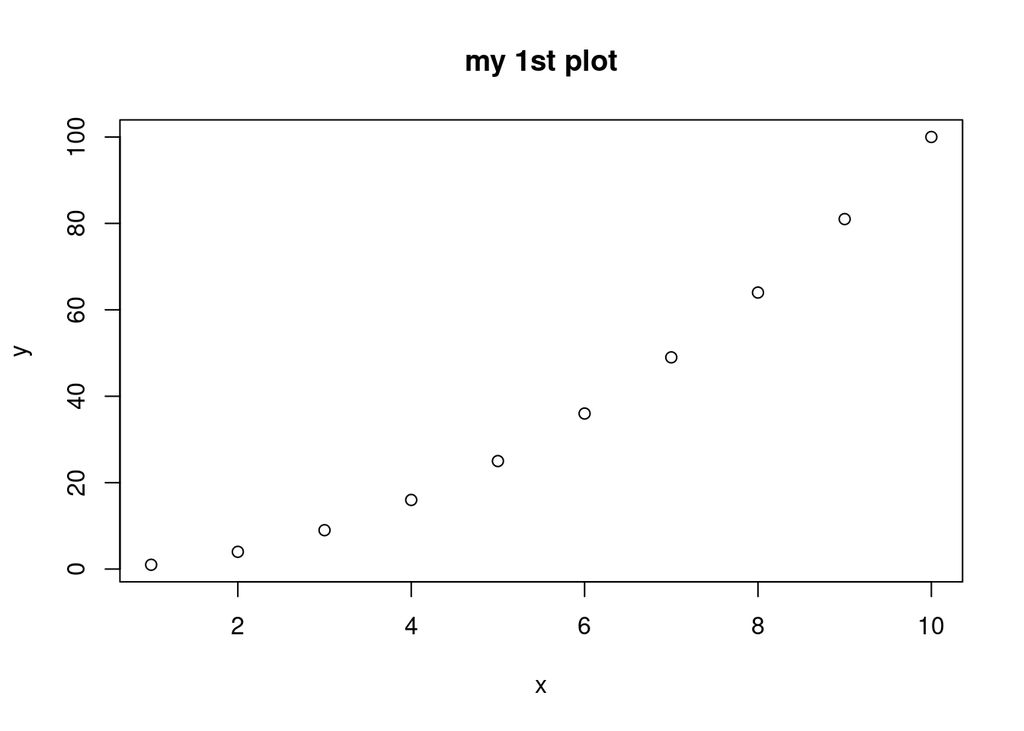

```r
plot(x, y, main = "my 1st plot")
```

## Axis Name

Change plot axis name

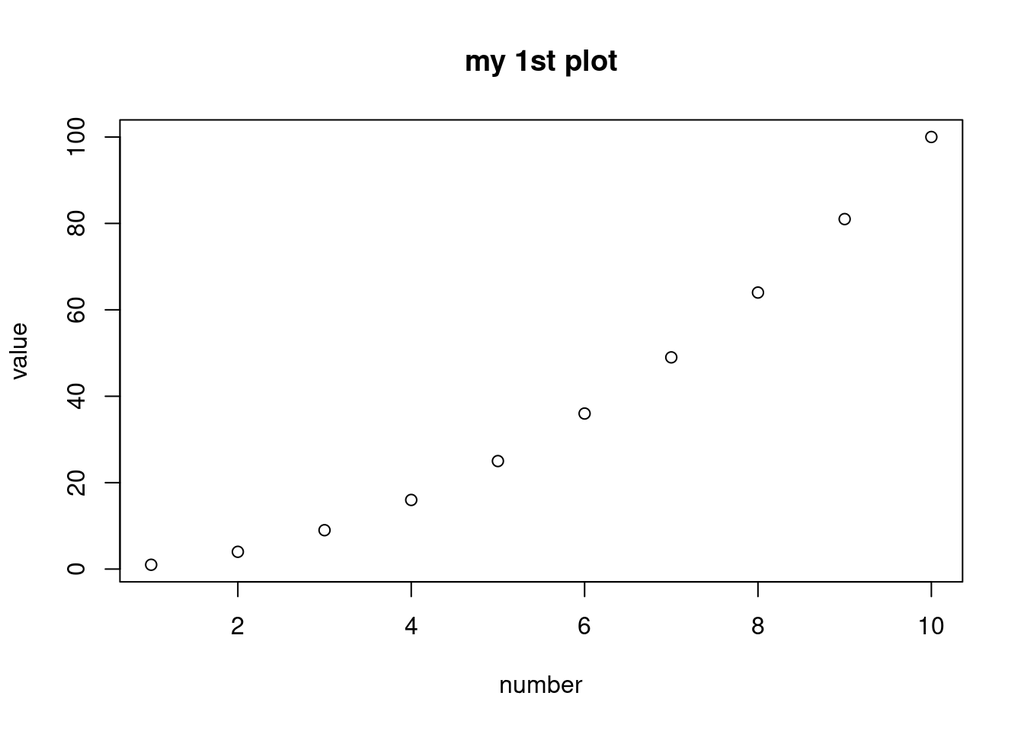

```r
plot(x, y, main = "my 1st plot", xlab = "number", ylab = "value")
```

## Adding more to a plot

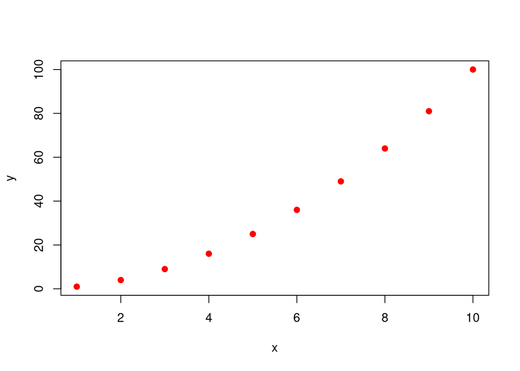

```r
x = 1:10
y = x**2
z = y + 1
plot(x, y, pch=19, col="red")
```

## Task

- plot data points and line in your favorite color and shape

## Fixing axis limits

- In R plots are static
- Adding new points can’t change the axis limits

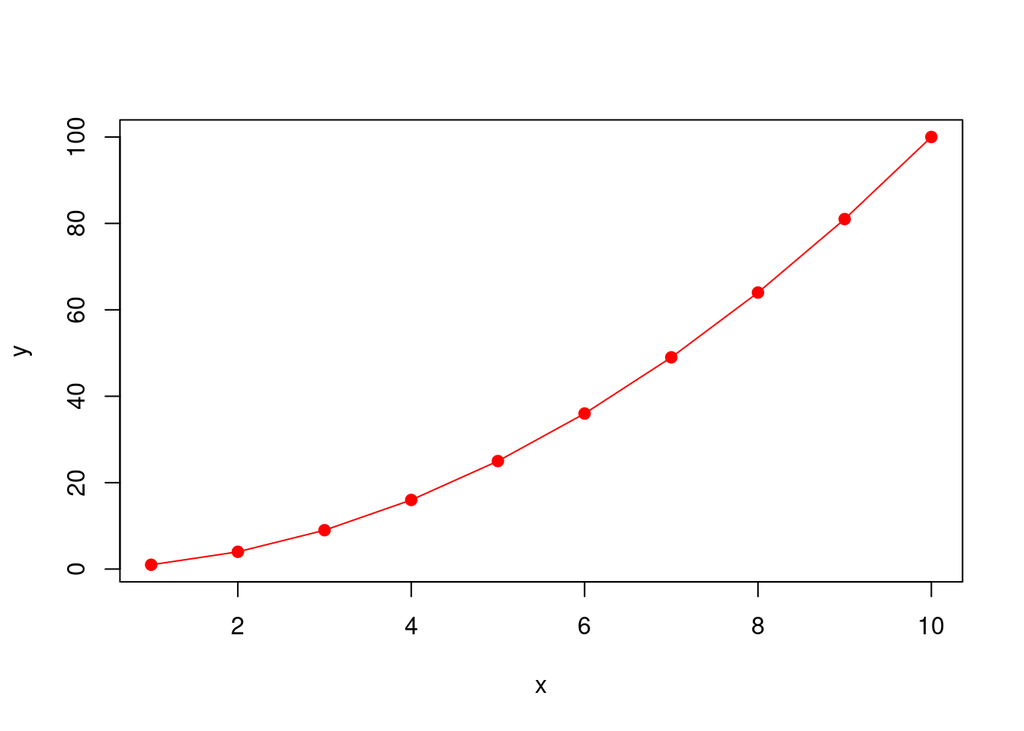

```r
plot(x, y, pch=19, col="red")
lines(x, y, col="red")
```

## Fixing axis limits

To overcome this issue specify the axis limits in advance

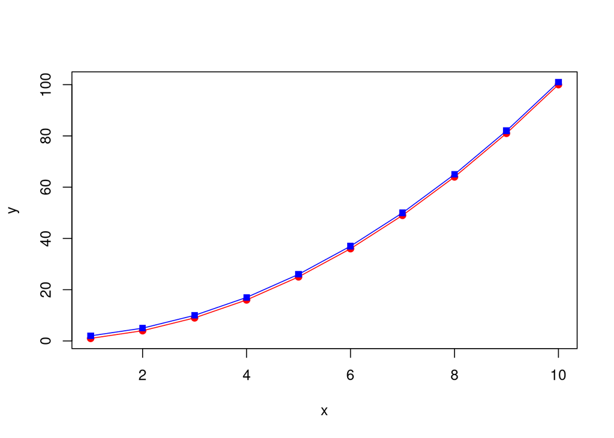

```r
ylimit = range(c(y,z))
plot(x, y, col="red", pch=19, ylim = ylimit)
lines(x, y, col="red")
points(x, z, col="blue", pch=15)
lines(x, z, col="blue")
```

## Adding legend

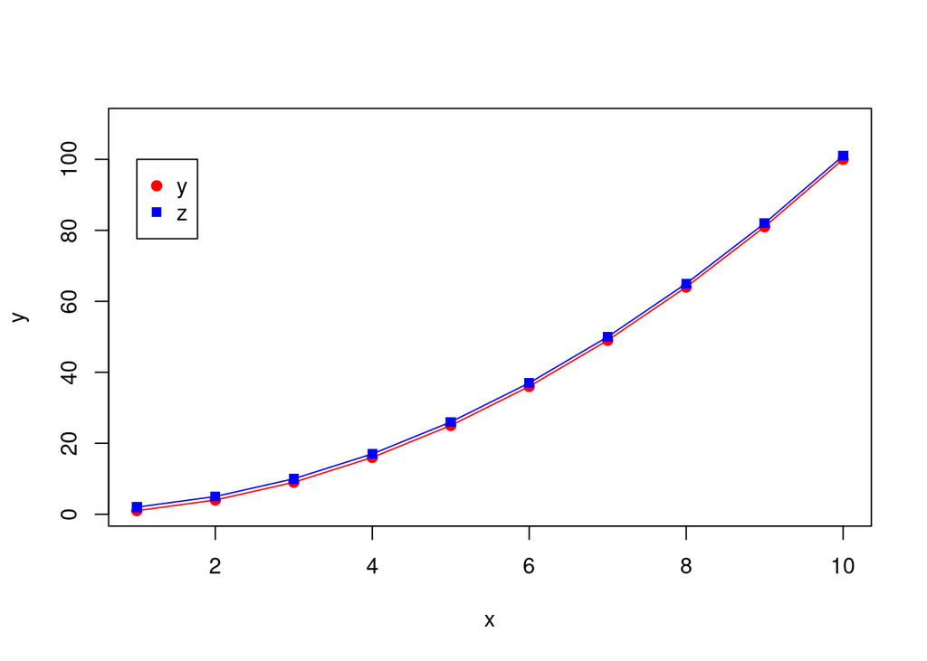

```r
plot(x, y, col="red", pch=19, ylim = c(1,110))
lines(x, y, col="red")
points(x, z, col="blue", pch=15)
lines(x, z, col="blue")
legend(1,100,legend=c("y","z"), col=c("red","blue"), pch=c(19,15))
```

## Barplot

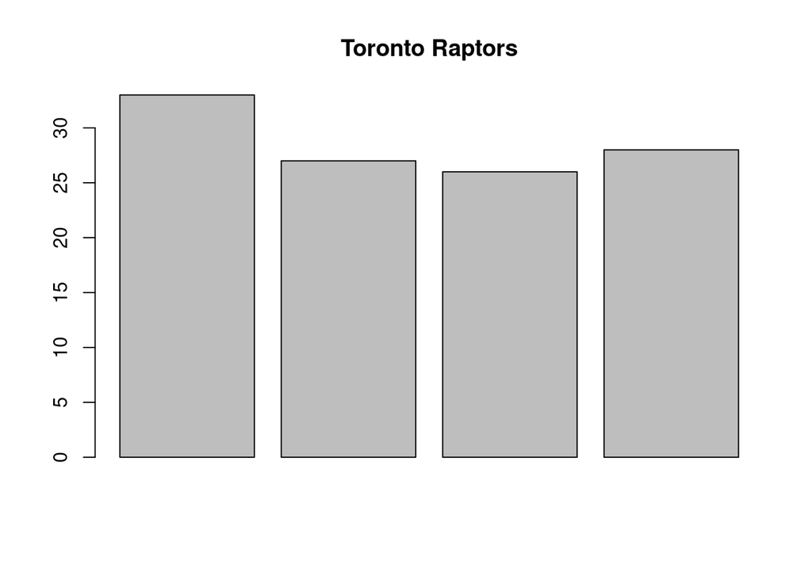

```r
raptors = c(33,27,26,28)
barplot(raptors, main="Toronto Raptors")
```

# How do we change the bar color?

## Barplot

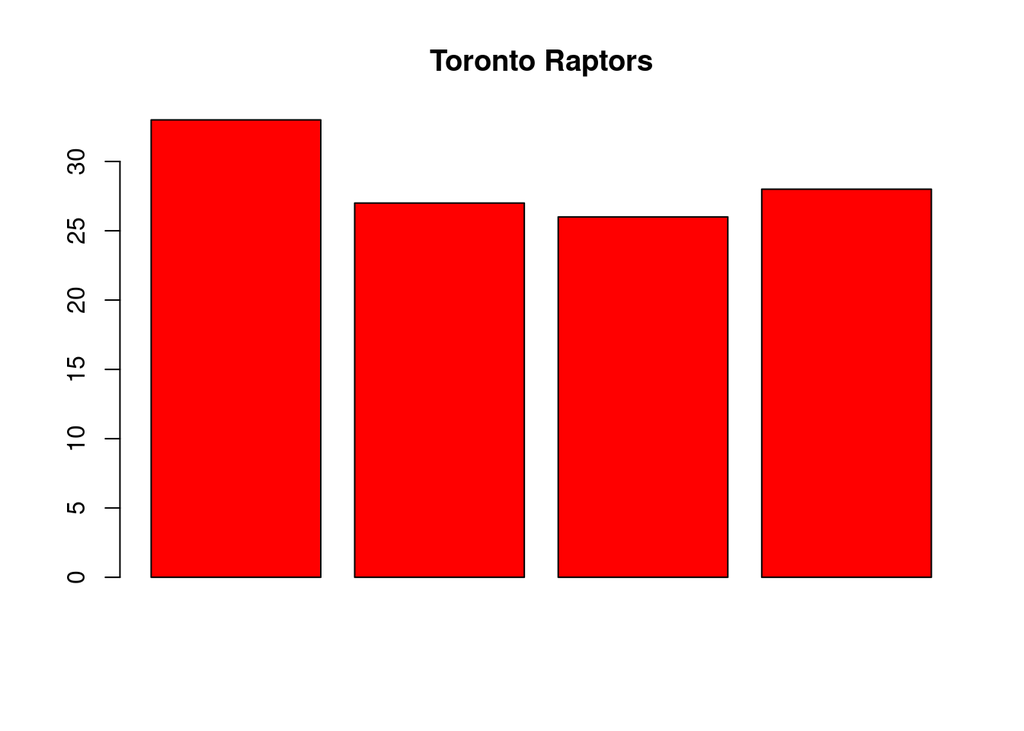

```r
raptors = c(33,27,26,28)
barplot(raptors, main="Toronto Raptors", col="red")
```

# How do we change border color?

## Barplot

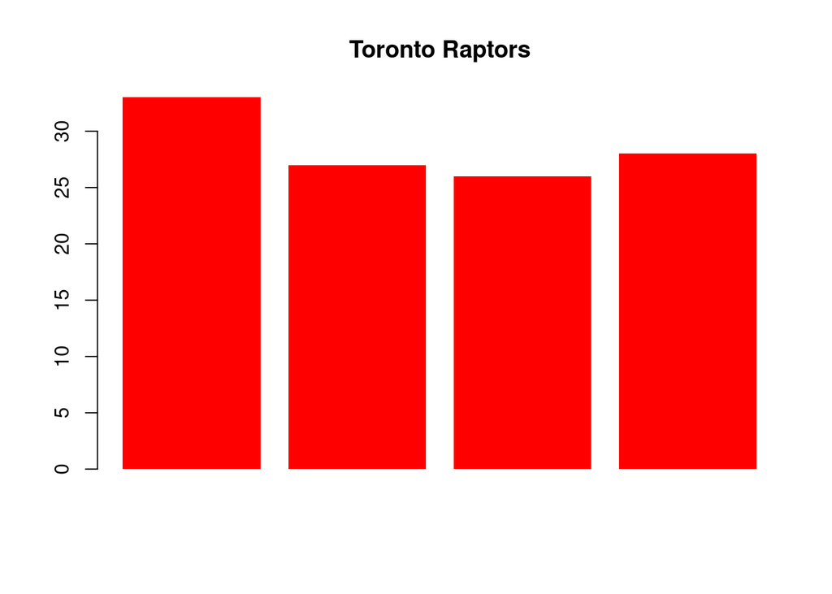

```r
raptors = c(33,27,26,28)
barplot(raptors, main="Toronto Raptors", col="red", border = NA)
```

## Barplot (Stacked)

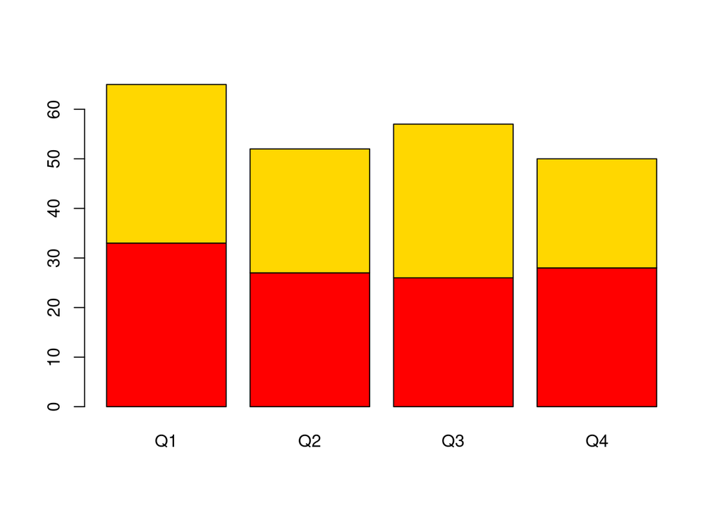

```r
raptors = c(33,27,26,28)
gsw = c(32, 25, 31, 22)
data = rbind(raptors, gsw)
colnames(data) = c("Q1", "Q2", "Q3", "Q4")
barplot(data, col=c("red", "gold"))
```

## Barplot (Grouped)

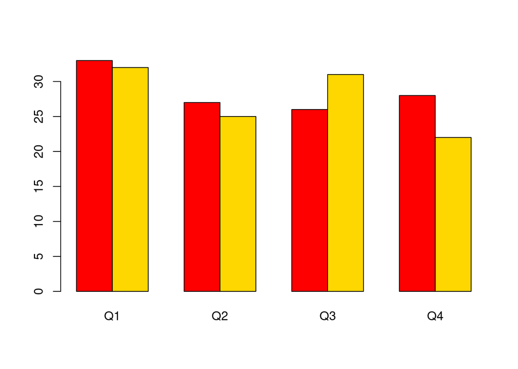

```r
barplot(data, col=c("red", "gold"), beside=TRUE)
```

## Barplot (add legend)

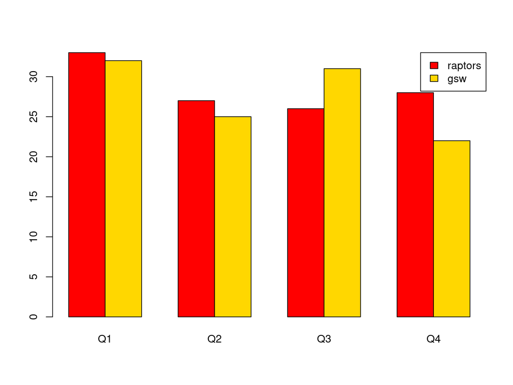

```r
barplot(data, col=c("red","gold"), beside=TRUE, legend=rownames(data),
        args.legend = list(x="topright"))
```

# Boxplot

## Boxplot

Same as barplot but data should be in column:

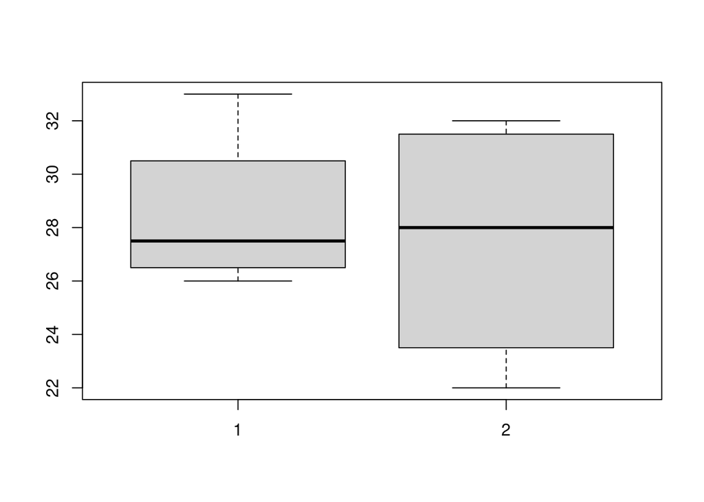

```r
raptors = c(33,27,26,28)
gsw = c(32, 25, 31, 22)
boxplot(raptors, gsw)
```

## Boxplot

Add names to the box:

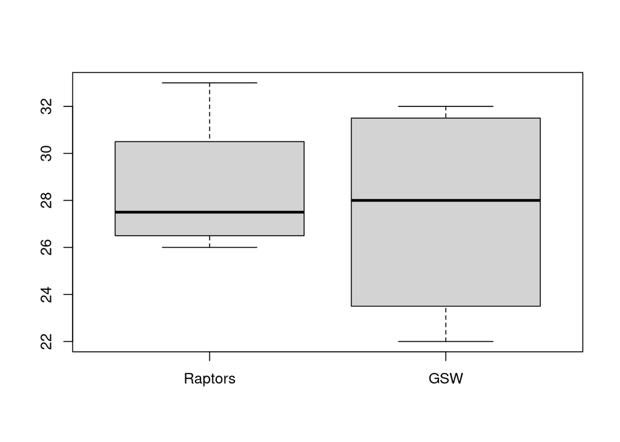

```r
raptors = c(33,27,26,28)
gsw = c(32, 25, 31, 22)
boxplot(raptors, gsw, names=c("Raptors","GSW"))
```

## Boxplot (color)

Here HTML color codes are used:

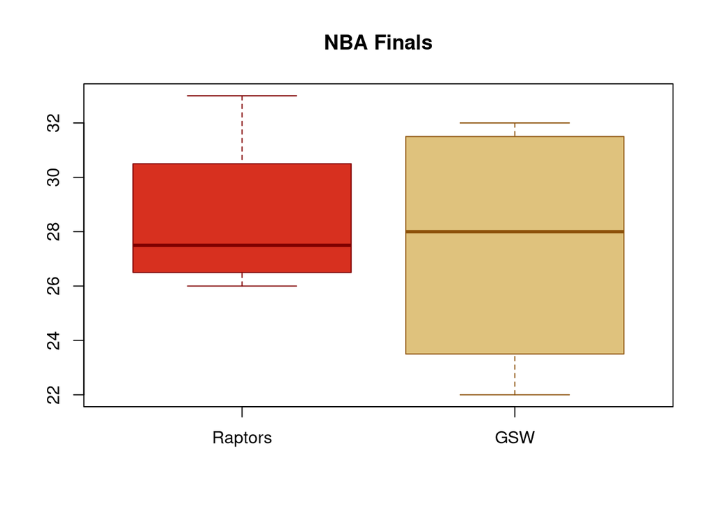

```r
boxplot(raptors, gsw, names=c("Raptors", "GSW"),
        col=c("#d7301f","#dfc27d"),
        border=c("#7f0000", "#8c510a"), main="NBA Finals")
```

## Task

- Add one more boxplot with data:

```r
bucks = c(23, 28, 25, 32)
```

## Using formula

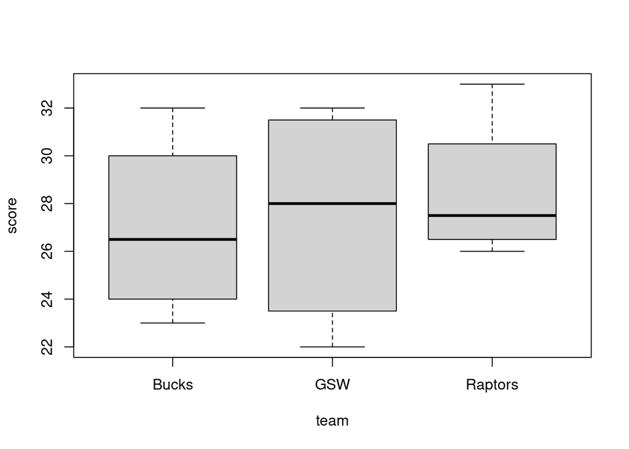

```r
bucks = c(23, 28, 25, 32)
df=data.frame(score=c(raptors, gsw, bucks),
              team= c(rep("Raptors", 4), rep("GSW", 4), rep("Bucks", 4)))
boxplot(score~team, data=df)
```

## Using formula

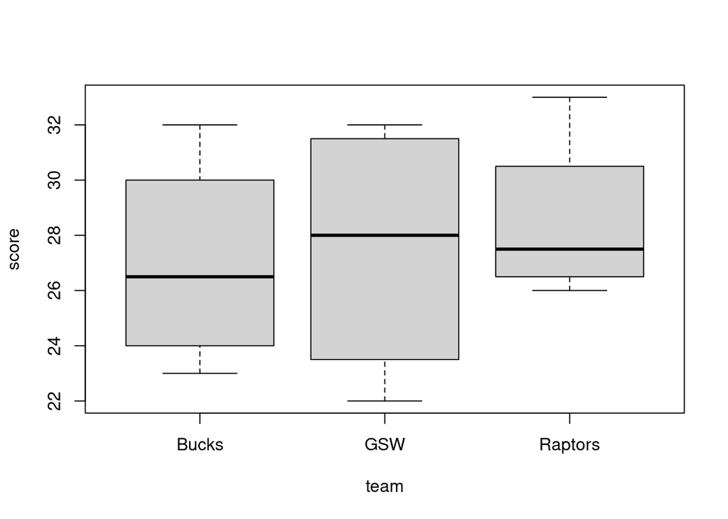

```r
bucks = c(23, 28, 25, 32)
df=data.frame(score=c(raptors, gsw, bucks),
              team=c(rep("Raptors",4), rep("GSW",4), rep("Bucks",4)))
boxplot(score~team, data=df)
```

## Saving Plots for Publication

- For publications use PDF or PNG format
- To save plot, open file just before plot function
- Don’t forget to close the file using **dev.off()**

```r
raptors = c(33,27,26,28)
gsw = c(32, 25, 31, 22)
bucks = c(23, 28, 25, 32)

pdf("NBA_finals.pdf", width = 4, height = 5)

boxplot(raptors, gsw, bucks, names=c("Raptors", "GSW", "Bucks"),
        col=c("#d7301f","#dfc27d", "#41ab5d"),
        border=c("#7f0000", "#8c510a", "#00441b"), main="NBA Finals")

dev.off()
```

## Saving Plots for Publication

```r
png("figure-1.png", width = 4, height = 5, units = 'in', res = 600)

boxplot(raptors, gsw, bucks, names=c("Raptors", "GSW", "Bucks"),
        col=c("#d7301f","#dfc27d", "#41ab5d"),
        border=c("#7f0000", "#8c510a", "#00441b"), main="NBA Finals")

dev.off()
```

## R data

- R comes with several inbuilt datasets

```r
data("iris")
head(iris)
```

|  | Sepal.Length | Sepal.Width | Petal.Length | Petal.Width | Species |
| --- | --- | --- | --- | --- | --- |
| 1 | 5.1 | 3.5 | 1.4 | 0.2 | setosa |
| 2 | 4.9 | 3.0 | 1.4 | 0.2 | setosa |
| 3 | 4.7 | 3.2 | 1.3 | 0.2 | setosa |
| 4 | 4.6 | 3.1 | 1.5 | 0.2 | setosa |
| 5 | 5.0 | 3.6 | 1.4 | 0.2 | setosa |
| 6 | 5.4 | 3.9 | 1.7 | 0.4 | setosa |

# packages

## Packages

- R comes with basic functions that you will use on a daily basis
- Sometime you will require specialized functions, written by others
- R package is a collection of functions and data written for a specific task

## Install a package

- To install an R package use the command **install.packages(“package name”)**
- In this example, we install the package **beeswarm**

```r
install.packages("beeswarm")
```

## Load a package

- Now we load the package and use a function from it

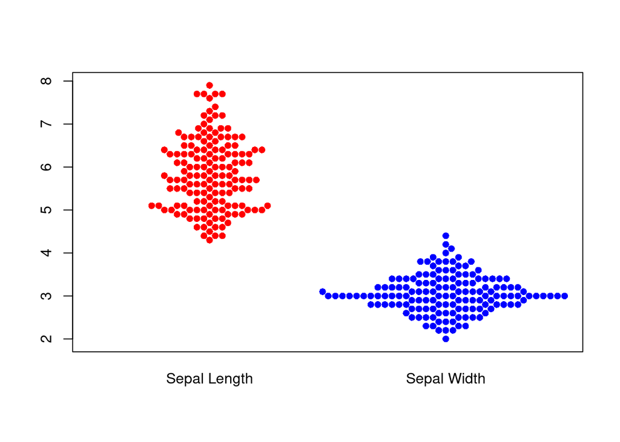

```r
library("beeswarm")
data("iris")
beeswarm(iris[, c("Sepal.Length", "Sepal.Width")],
         pch = 16, col=c("red", "blue"),
         labels = c("Sepal Length", "Sepal Width"))
```

## Finding Help

- All functions in R are documented
- **?** can be used to find documents

```r
?beeswarm
```

- **??** can be used to find something anywhere in R documents

```r
??beeswarm
```

# Now find more about the function **mean**

## Finding R package

- Google the problem
- Look into CRAN website www.cran.r-project.org/web/packages/
- Look into Bioconductor repo www.bioconductor.org
- ** Note:** packages at Bioconductor uses a different command to install that is:

```r
BiocManager::install("package name")
```

# reading and writing files

## Save data

- R can save data in different formats
- Data can be saved in R native format

```r
raptors = c(33,27,26,28)
gsw = c(32, 25, 31, 22)
df = cbind(raptors, gsw)
saveRDS(df, "my_data.rds")
```

- To read it use readRDS function

```r
mydata = readRDS("my_data.rds")
head(mydata)
```

```
##      raptors gsw
## [1,]      33  32
## [2,]      27  25
## [3,]      26  31
## [4,]      28  22
```

## Save data

- R can save data in CSV formats

```r
write.csv(df,file="my_data.csv")
```

- To read it use read.csv function

```r
mydata2 = read.csv("my_data.csv", row.names = 1)
head(mydata2)
```

|  | raptors | gsw |
| --- | --- | --- |
| 1 | 33 | 32 |
| 2 | 27 | 25 |
| 3 | 26 | 31 |
| 4 | 28 | 22 |

## Excel files

- R package **openxlsx** can read and write Excel files
- Task: Install the package **openxlsx** and load it

## Write excel files

- To install the package

```r
install.packages("openxlsx")
```

- To write the Excel file

```r
library(openxlsx)
write.xlsx(df, "myData.xlsx")
```

- Now open the **myData.xlsx** file, add one more row, save and close the file

## Read excel files

```r
myxl = read.xlsx("myData.xlsx")
head(myxl)
```

[output not shown]

## Caution

- Large Excel files may take a long time and memory to read/write
- Use R native **RDS** files to read and write the data during the analysis
- To share data, prefer **CSV** format then Excel
- Save only final results/data in Excel format

# R Biostat. and data analysis

## R Biostat. basics

Useful functions:

- sum(x) –> Sums the elements in x
- prod(x) –> Product of the elements in x
- max(x) –> Maximum element in x
- min(x) –> Minimum element in x
- range(x) –> Range (min to max) of elements in x

## R Biostat. basics

Useful functions:

- mean(x) –> Mean (average value) of elements in x.
- median(x) –> Median (middle value) of elements in x
- var(x) –> Variance of elements in x
- sd(x) –> Standard deviation of element in x
- cor(x,y) –> Correlation between x and y
- cov(x,y) –> Covariance between x and y
- quantile(x,p) –> The pth quantile of x

## R Biostat. basics

Example: patients data

```r
set.seed(21341)
patients.df <- data.frame(
  "ID"=paste0("p",1:100)
  ,"Gender"=factor(sample(c("F","M"),100,replace = T))
  ,"Stage"=factor(sample(c("I","II","III","IV"),100,replace = T))
  ,"Age"=as.integer(rgamma(100,shape = 50))
  ,"TumorVolume"=rgamma(100,shape = 10)
  ,stringsAsFactors = F)

head(patients.df)
```

|  | ID | Gender | Stage | Age | TumorVolume |
| --- | --- | --- | --- | --- | --- |
| 1 | p1 | M | IV | 43 | 9.255460 |
| 2 | p2 | M | I | 56 | 13.032624 |
| 3 | p3 | F | III | 59 | 15.205465 |
| 4 | p4 | F | II | 48 | 10.720874 |
| 5 | p5 | M | IV | 57 | 8.929090 |
| 6 | p6 | M | III | 34 | 8.440177 |

## R Biostat. basics

```r
quantile(patients.df$Age)
```

```
##   0%  25%  50%  75% 100%
##   33   43   49   53   77
```

```r
summary(patients.df$Age)
```

```
##    Min. 1st Qu.  Median    Mean 3rd Qu.    Max.
##   33.00   43.00   49.00   48.67   53.00   77.00
```

## R Biostat. basics

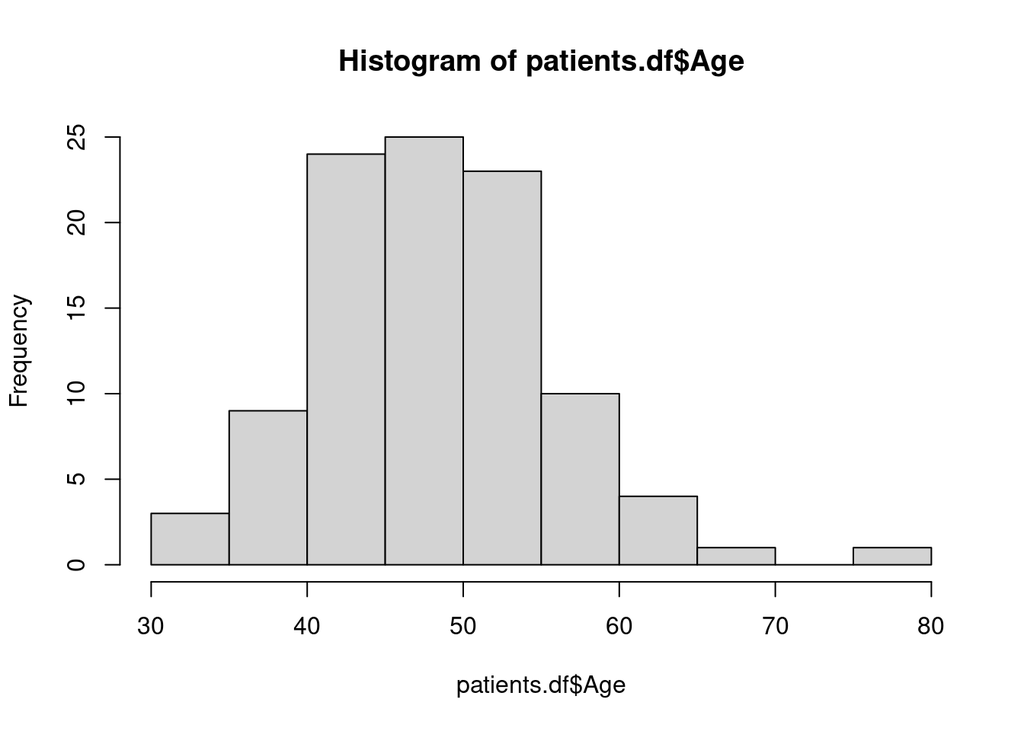

```r
hist(patients.df$Age)
```

## R Biostat. basics

```r
summary(patients.df$Stage)
```

```
##   I  II III  IV
##  22  23  30  25
```

```r
table(patients.df$Stage)
```

```
##
##   I  II III  IV
##  22  23  30  25
```

## R Biostat. basics

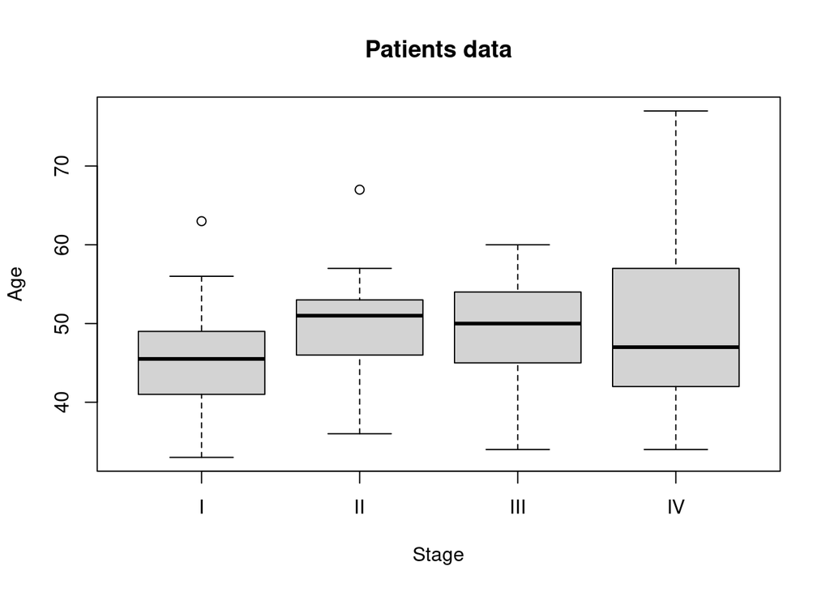

```r
boxplot(Age ~ Stage, patients.df
  , ylab="Age",xlab="Stage",main="Patients data")
```

## R Biostat. basics

T-test and Wilcoxon rank sum test

- T-test measures the difference in mean between two independent populations [assumes normal distribution]
- Wilcoxon rank sum test measures the difference in the median between two independent populations [non-parametric]

## R Biostat. basics

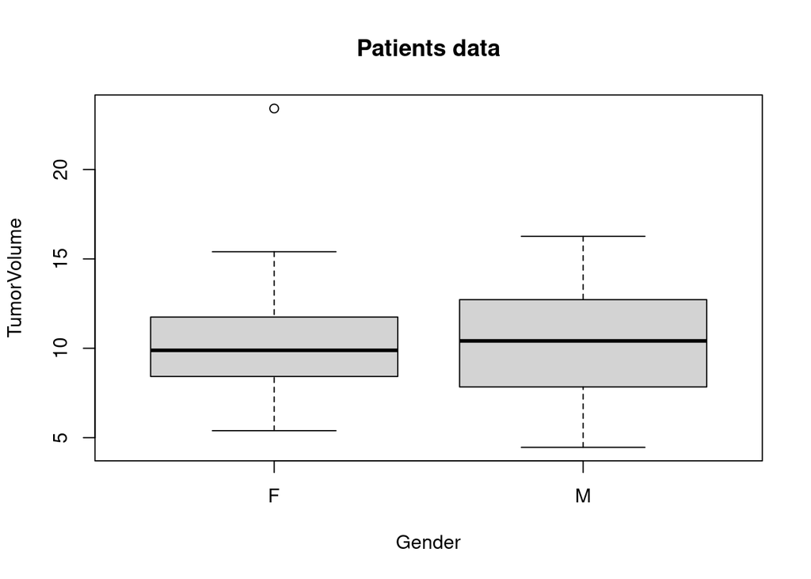

```r
boxplot(TumorVolume ~ Gender, patients.df
  , ylab="TumorVolume",xlab="Gender",main="Patients data")
```

## R Biostat. basics

Let’s use the Wilcoxon rank sum test to see if female and male patients are significantly different in regards to Tumor Volume

```r
  wilcox.test(x = patients.df$TumorVolume[patients.df$Gender=="M"]
              ,y = patients.df$TumorVolume[patients.df$Gender=="F"]
              ,mu = 0,alternative = "two.sided",paired = F,T)
```

```
##
##  Wilcoxon rank sum exact test
##
## data:  patients.df$TumorVolume[patients.df$Gender == "M"] and patients.df$TumorVolume[patients.df$Gender == "F"]
## W = 1301, p-value = 0.6638
## alternative hypothesis: true location shift is not equal to 0
```

## R Biostat. basics

Let’s check the correlation between Age and Tumor volume

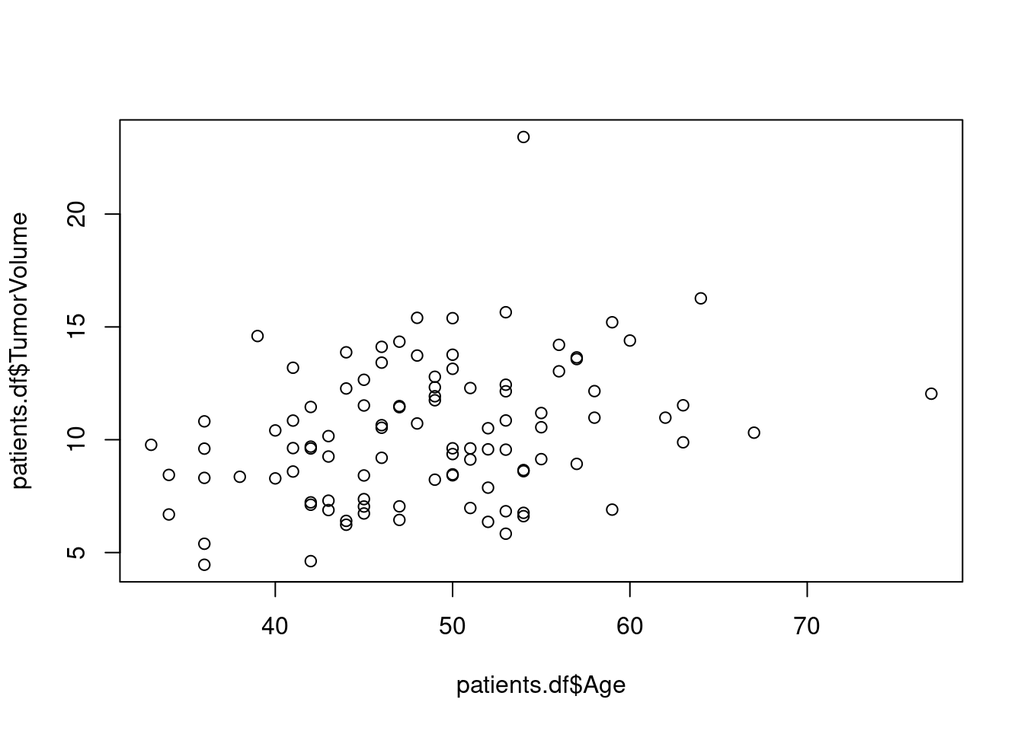

```r
plot(patients.df$Age,patients.df$TumorVolume)
```

## R Biostat. basics

- Pearson product moment correlation: The Pearson correlation evaluates the linear relationship between two continuous variables.
- Spearman rank-order correlation: The Spearman correlation evaluates the monotonic relationship between two continuous or ordinal variables.

## R Biostat. basics

Let’s check the correlation between Age and Tumor volume

```r
cor.test(patients.df$Age,patients.df$TumorVolume)
```

```
##
##  Pearson's product-moment correlation
##
## data:  patients.df$Age and patients.df$TumorVolume
## t = 3.1949, df = 98, p-value = 0.001882
## alternative hypothesis: true correlation is not equal to 0
## 95 percent confidence interval:
##  0.1178229 0.4749021
## sample estimates:
##       cor
## 0.3071332
```

# Project

## Project

1- Download the following file from: https://drive.google.com/drive/folders/1Jqa5KxKyfYqMMkk1IOwKihOZw-IeedxT

2- Find the if there is a significant difference between TNBC and nonTNBC samples based on these genes [ESR1, PGR, ERBB2] and show that in a plot. 3- Compute the pairwise correlation between all the samples and show that in a plot.

Hint: Install and use package **corrplot**